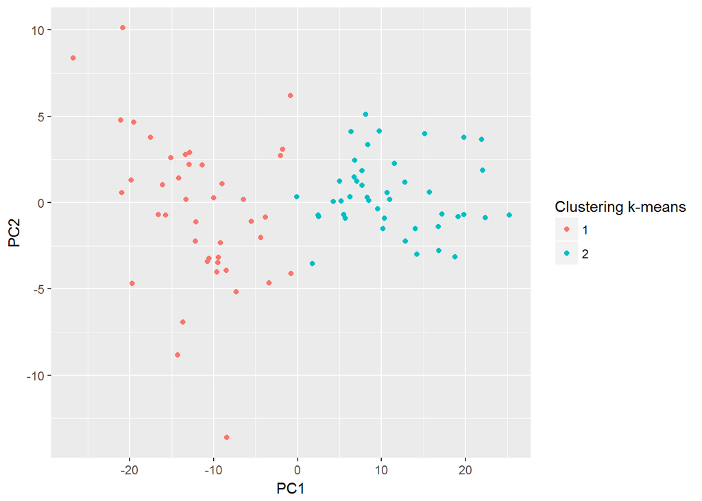

```r
#Colored by kmeans
kmeansplot <- ggplot(data = as.data.frame(PCAgeneslimited$x), aes(x = PC1, y = PC2, color = as.factor(kmeanssamples$cluster))) + geom_point() + scale_color_discrete(name = "Clustering k-means")
kmeansplot
```

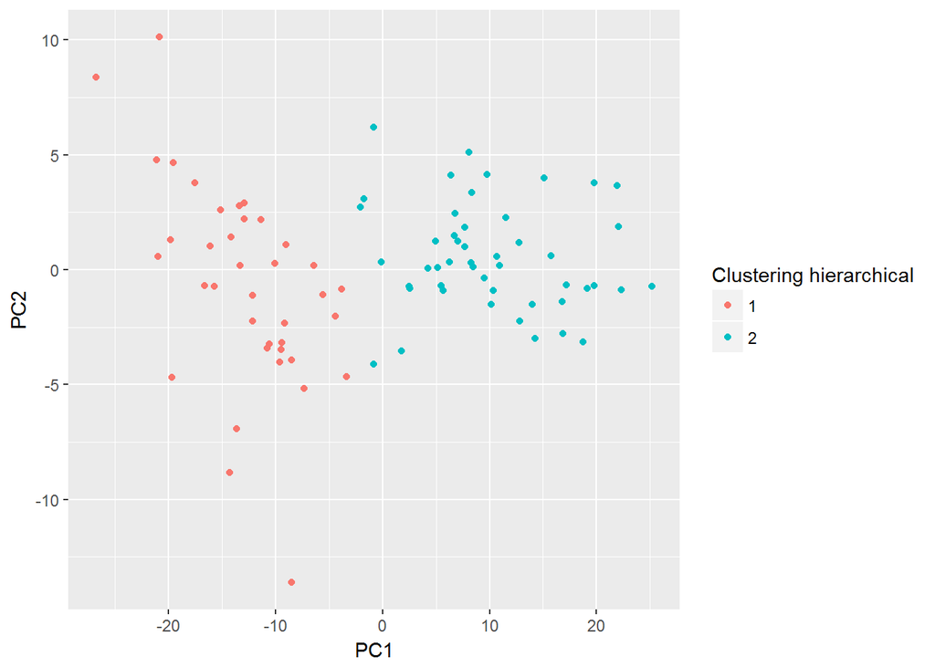

```r
#Colored by hierarchical clustering
hclustplot <- ggplot(data = as.data.frame(PCAgeneslimited$x), aes(x = PC1, y = PC2, color = as.factor(hclusterssamples))) + geom_point() + scale_color_discrete(name = "Clustering hierarchical")
hclustplot
```

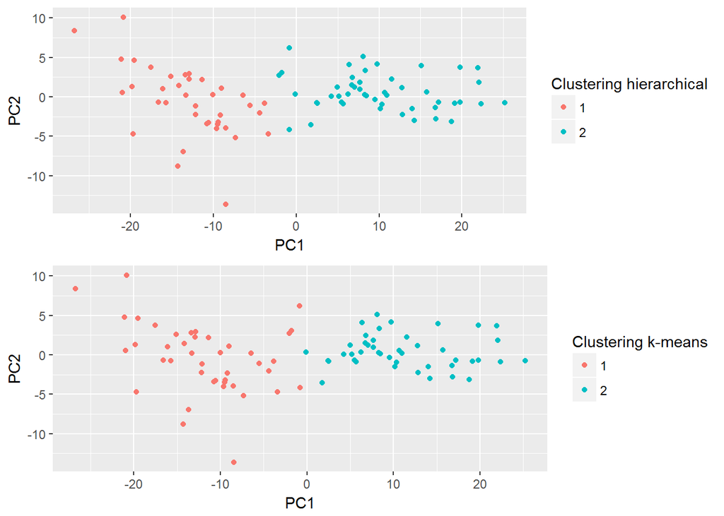

```r
#I arrange the plots within the same window
plots <- list(hclustplot, kmeansplot)
do.call(grid.arrange, plots)
```

## Exercise 5

1. Display the results from the hierarchical clustering by a heatmap plot, using the pheatmap() from the pheatmap package. Use cutree_col=2.

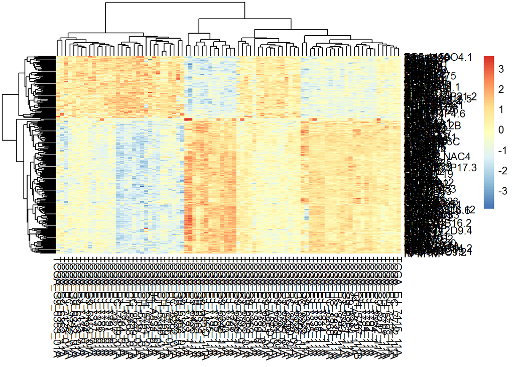

```r
#install.packages("pheatmap")
library(pheatmap)
pheatmap(PRADnormlimited)
```

2. Then repeat the hierarchical clustering by genes using: . manhattan distance, single linkage and k=2;

```r
#install.packages("dendextend")
library(dendextend)
```

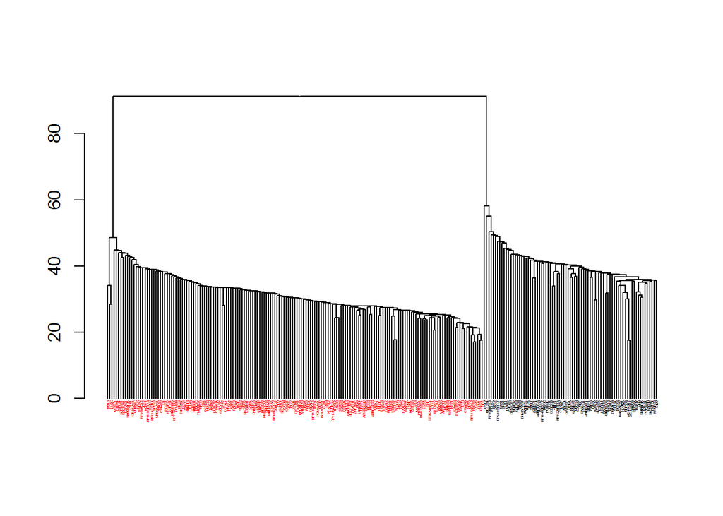

```r
#I calculate manhattan distance between genes
manhattangenes <- dist(PRADnormlimited, method = "manhattan")

# I perform the hierarchical clustering for genes with manhattan distance and single linkage and check if it looks reasonable
hclustmanhattangenes <- hclust(manhattangenes, method = "single")
dendmanhattan <- as.dendrogram(hclustmanhattangenes)
labels_colors(dendmanhattan) <- cutree(hclustmanhattangenes, 2)[order.dendrogram(dendmanhattan)]
labels_cex(dendmanhattan) <- 0.2
plotmanhattan <- plot(dendmanhattan)
```

```r
plotmanhattan
```

. euclidean distance, complete linkage and k=2.

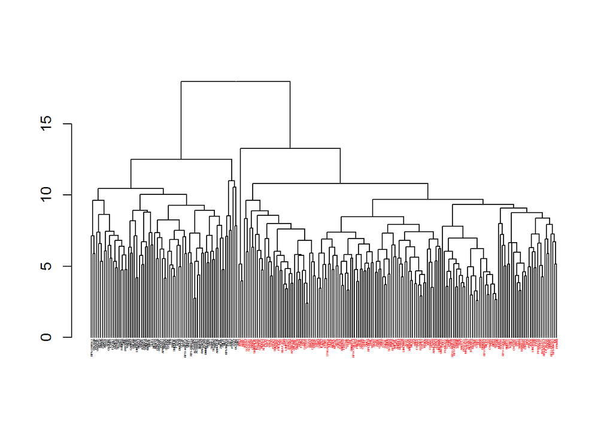

```r
#I calculate euclidean distance between genes
euclideangenes <- dist(PRADnormlimited, method = "euclidean")

# I perform the hierarchical clustering for genes with euclidean distance and complete linkage and check if it looks reasonable
hclusteuclideangenes <- hclust(euclideangenes, method = "complete")
dendeuclidean <- as.dendrogram(hclusteuclideangenes)
labels_colors(dendeuclidean) <- cutree(hclusteuclideangenes, 2)[order.dendrogram(dendeuclidean)]
labels_cex(dendeuclidean) <- 0.2
ploteuclidean <- plot(dendeuclidean)
```

```r
ploteuclidean
```

Display in the same window the dendrograms with the results and use dendextend package to highlight the two clusters in each dendrogram. Set up the plots using par() function indicating a proper layout of the two plots and a proper fontsize of the labels.

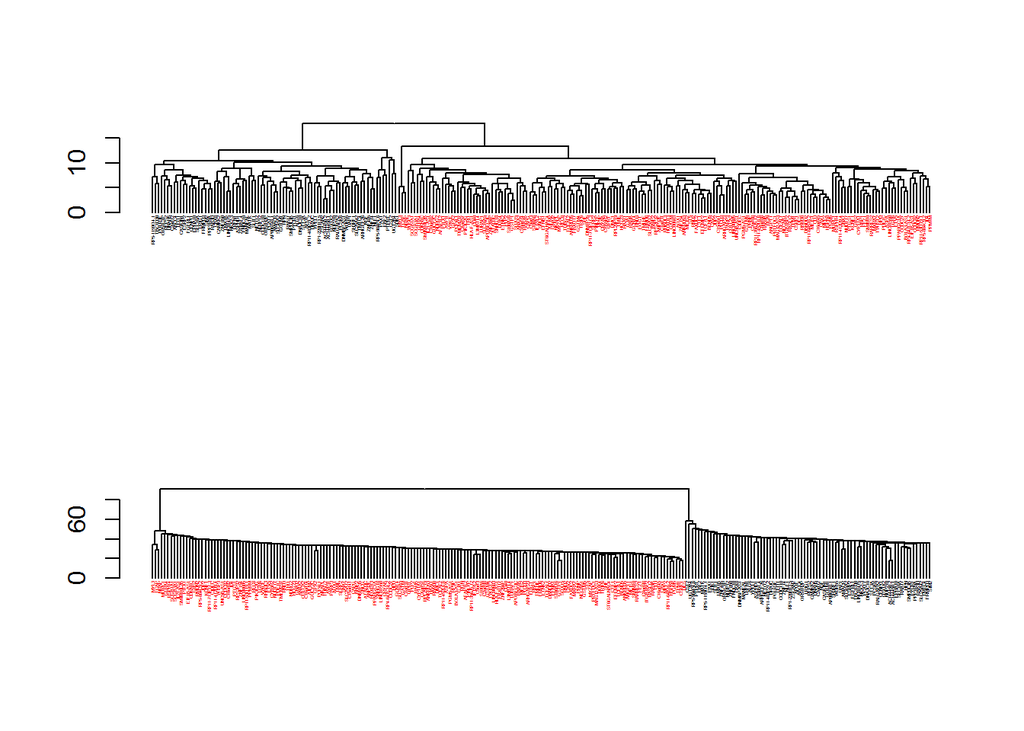

```r
#I plot the figures within the same window with par()
par(mfrow = c(2, 1))
plot(dendeuclidean)
plot(dendmanhattan)
```

3. Display again the heatmap, adding colored bars to: . the samples, showing the information about the case (i.e. Tumor or Normal) and the age, dividing the patients into two groups: those with age below 55 years old and those with age equal or above 55 years old; . the genes, showing the results of the two hierarchical clustering performed in point 2.

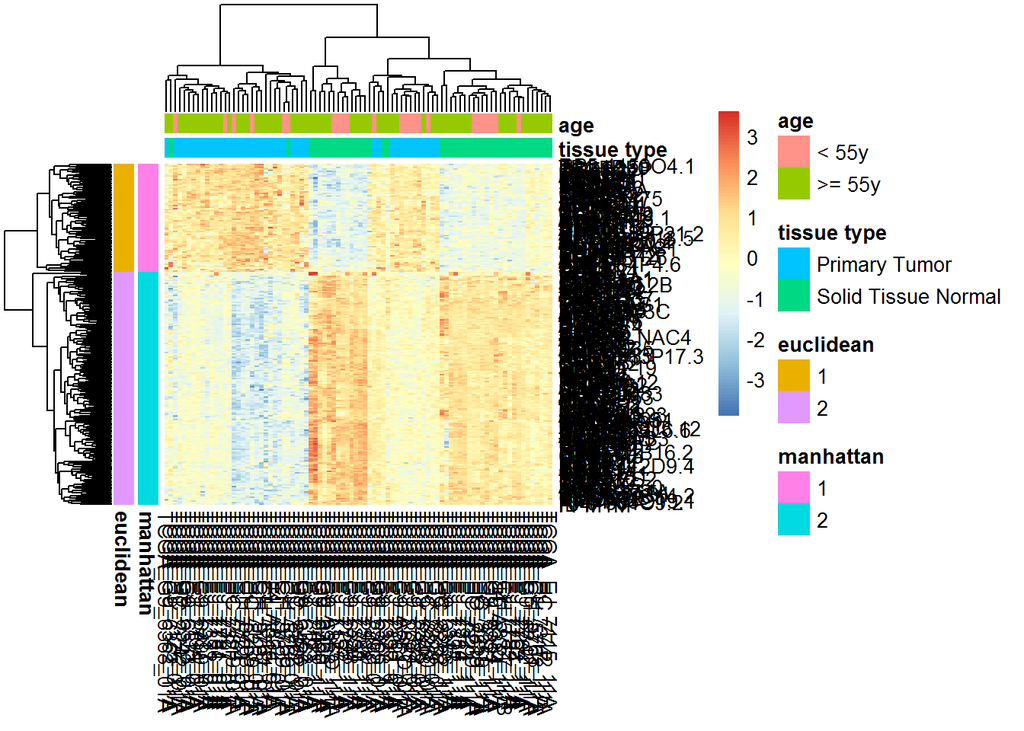

```r
#COLUMNS

#I create the dataframe with the information on tissue type
coldf <- as.data.frame(PRADsample[ , 2])
rownames(coldf) <- PRADsample[ , 1]
colnames(coldf) <- "tissue type"

#I add the information on age
coldf$age <- ifelse(PRADsample[ , 3] >= 55, ">= 55y", "< 55y")

#ROWS

#I create the dataframe with the information on manhattan classification
rowdf <- as.data.frame(as.factor(cutree(hclustmanhattangenes, 2)))
rownames(rowdf) <- rownames(PRADnormlimited)
colnames(rowdf) <- "manhattan"

#I add the information on
rowdf$euclidean <- as.factor(cutree(hclusteuclideangenes, 2))

#Plot
pheatmap(PRADnormlimited, annotation_col = coldf, annotation_row = rowdf)
```

## Exercise 6

Consider only the primary tumors in PRAD dataset (using the top 250 genes) and identify sub-groups of samples that might correspond to different cancer sub-types.

```r
#I select the columns of the dataset that are primary tumor and check if the resulting database looks resonable
samplesprimary <- PRADsample[PRADsample$Condition == "Primary Tumor" , 1]
PRADprimary <- PRADnormlimited[ , colnames(PRADnormlimited) %in% samplesprimary]
PRADprimary[1:10, 1:5]
```

```
##           TCGA_G9_6496_01A TCGA_EJ_7781_01A TCGA_EJ_7314_01A
## SLIT1          -0.64186341        1.4555808        1.2555313
## EPHA10          1.10280518        0.8019181        1.1883140
## CTF1           -0.91117831       -0.6146569       -0.8429234
## LINC01475       2.20486177        0.7355249        1.5050851
## TRIP6           0.05275005       -1.0162110       -0.8170603
## GSTP1          -0.66370490       -0.8965549       -0.4961641
## GATM           -0.97692227       -0.2291437       -0.4535930
## DOK4           -0.89087433       -1.1896860       -0.2774729
## AMACR           0.50307076        1.0928566        0.3583999
## BEND5          -0.85415741       -0.4326828       -1.0913260
##           TCGA_EJ_7331_01A TCGA_G9_6348_01A
## SLIT1          -0.01037749      1.455755350
## EPHA10          1.02588696      0.520450313
## CTF1           -0.65326860     -0.002600939
## LINC01475      -0.94467594      0.189791896
## TRIP6          -0.83297886      0.316000165
## GSTP1          -0.88670173      0.226136409
## GATM           -0.71088687     -0.479281125
## DOK4           -0.93785045     -0.188018240
## AMACR           1.20063484      1.413065846
## BEND5          -0.81298117     -0.430248772
```

A plot of the within groups sum of squares by number of clusters extracted can help to determine the appropriate number of clusters. Perform the hierarchical clustering per sample, using euclidean distance and single, average and complete linkage. Use the function cluster.stats() from fpc package and plot, for k=2:10, the within sum of squares (within.cluster.ss) and the average silhouette (avg.silwidth) into two separate plots but in the same window, highlighting the 3 linkage approaches differently. Which linkage method and number of clusters are the best choice?

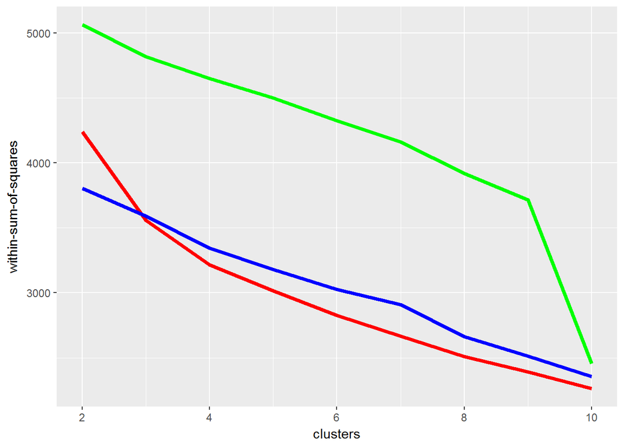

```r
#I calculate euclidean distance between samples
euclideansamples <- dist(t(PRADprimary))

#I perform the hierarchical clustering using single, average, and complete linkage
hclustsingle <- hclust(euclideansamples, method = "single")
hclustaverage <- hclust(euclideansamples, method = "average")
hclustcomplete <- hclust(euclideansamples, method = "complete")

#I define the clusters stats for each group
clustersinglek2 <- cluster.stats(euclideansamples, clustering = cutree(hclustsingle, 2))
clustersinglek3 <- cluster.stats(euclideansamples, clustering = cutree(hclustsingle, 3))
clustersinglek4 <- cluster.stats(euclideansamples, clustering = cutree(hclustsingle, 4))
clustersinglek5 <- cluster.stats(euclideansamples, clustering = cutree(hclustsingle, 5))
clustersinglek6 <- cluster.stats(euclideansamples, clustering = cutree(hclustsingle, 6))
clustersinglek7 <- cluster.stats(euclideansamples, clustering = cutree(hclustsingle, 7))
clustersinglek8 <- cluster.stats(euclideansamples, clustering = cutree(hclustsingle, 8))
clustersinglek9 <- cluster.stats(euclideansamples, clustering = cutree(hclustsingle, 9))
clustersinglek10 <- cluster.stats(euclideansamples, clustering = cutree(hclustsingle, 10))

clusteraveragek2 <- cluster.stats(euclideansamples, clustering = cutree(hclustaverage, 2))
clusteraveragek3 <- cluster.stats(euclideansamples, clustering = cutree(hclustaverage, 3))
clusteraveragek4 <- cluster.stats(euclideansamples, clustering = cutree(hclustaverage, 4))
clusteraveragek5 <- cluster.stats(euclideansamples, clustering = cutree(hclustaverage, 5))
clusteraveragek6 <- cluster.stats(euclideansamples, clustering = cutree(hclustaverage, 6))
clusteraveragek7 <- cluster.stats(euclideansamples, clustering = cutree(hclustaverage, 7))
clusteraveragek8 <- cluster.stats(euclideansamples, clustering = cutree(hclustaverage, 8))
clusteraveragek9 <- cluster.stats(euclideansamples, clustering = cutree(hclustaverage, 9))
clusteraveragek10 <- cluster.stats(euclideansamples, clustering = cutree(hclustaverage, 10))

clustercompletek2 <- cluster.stats(euclideansamples, clustering = cutree(hclustcomplete, 2))
clustercompletek3 <- cluster.stats(euclideansamples, clustering = cutree(hclustcomplete, 3))
clustercompletek4 <- cluster.stats(euclideansamples, clustering = cutree(hclustcomplete, 4))
clustercompletek5 <- cluster.stats(euclideansamples, clustering = cutree(hclustcomplete, 5))
clustercompletek6 <- cluster.stats(euclideansamples, clustering = cutree(hclustcomplete, 6))
clustercompletek7 <- cluster.stats(euclideansamples, clustering = cutree(hclustcomplete, 7))
clustercompletek8 <- cluster.stats(euclideansamples, clustering = cutree(hclustcomplete, 8))
clustercompletek9 <- cluster.stats(euclideansamples, clustering = cutree(hclustcomplete, 9))
clustercompletek10 <- cluster.stats(euclideansamples, clustering = cutree(hclustcomplete, 10))

sumofsquaresdfsingle <- data.frame(2 : 10, c(clustersinglek2$within.cluster.ss, clustersinglek3$within.cluster.ss, clustersinglek4$within.cluster.ss, clustersinglek5$within.cluster.ss, clustersinglek6$within.cluster.ss, clustersinglek7$within.cluster.ss, clustersinglek8$within.cluster.ss, clustersinglek9$within.cluster.ss, clustersinglek10$within.cluster.ss))
colnames(sumofsquaresdfsingle) <- c("clusters", "withinss")

sumofsquaresdfaverage <- data.frame(2 : 10, c(clusteraveragek2$within.cluster.ss, clusteraveragek3$within.cluster.ss, clusteraveragek4$within.cluster.ss, clusteraveragek5$within.cluster.ss, clusteraveragek6$within.cluster.ss, clusteraveragek7$within.cluster.ss, clusteraveragek8$within.cluster.ss, clusteraveragek9$within.cluster.ss, clusteraveragek10$within.cluster.ss))
colnames(sumofsquaresdfaverage) <- c("clusters", "withinss")

sumofsquaresdfcomplete <- data.frame(2 : 10, c(clustercompletek2$within.cluster.ss, clustercompletek3$within.cluster.ss, clustercompletek4$within.cluster.ss, clustercompletek5$within.cluster.ss, clustercompletek6$within.cluster.ss, clustercompletek7$within.cluster.ss, clustercompletek8$within.cluster.ss, clustercompletek9$within.cluster.ss, clustercompletek10$within.cluster.ss))
colnames(sumofsquaresdfcomplete) <- c("clusters", "withinss")


ss <- ggplot(data = NULL, aes(x = clusters, y = withinss)) +
  geom_line(data = sumofsquaresdfsingle, color = "green", lwd = 1.5) +
  geom_line(data = sumofsquaresdfcomplete, color = "red", lwd = 1.5) +
  geom_line(data = sumofsquaresdfaverage, color = "blue", lwd = 1.5) +
  ylab("within-sum-of-squares")
ss
```

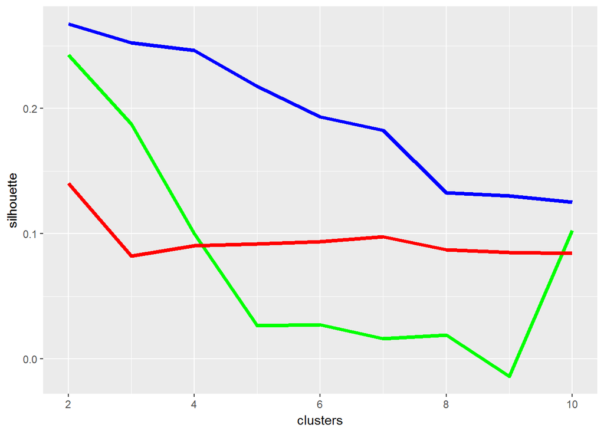

```r
sildfsingle <- data.frame(2 : 10, c(clustersinglek2$avg.silwidth, clustersinglek3$avg.silwidth, clustersinglek4$avg.silwidth, clustersinglek5$avg.silwidth, clustersinglek6$avg.silwidth, clustersinglek7$avg.silwidth, clustersinglek8$avg.silwidth, clustersinglek9$avg.silwidth, clustersinglek10$avg.silwidth))
colnames(sildfsingle) <- c("clusters", "silhouette")

sildfaverage <- data.frame(2 : 10, c(clusteraveragek2$avg.silwidth, clusteraveragek3$avg.silwidth, clusteraveragek4$avg.silwidth, clusteraveragek5$avg.silwidth, clusteraveragek6$avg.silwidth, clusteraveragek7$avg.silwidth, clusteraveragek8$avg.silwidth, clusteraveragek9$avg.silwidth, clusteraveragek10$avg.silwidth))
colnames(sildfaverage) <- c("clusters", "silhouette")

sildfcomplete <- data.frame(2 : 10, c(clustercompletek2$avg.silwidth, clustercompletek3$avg.silwidth, clustercompletek4$avg.silwidth, clustercompletek5$avg.silwidth, clustercompletek6$avg.silwidth, clustercompletek7$avg.silwidth, clustercompletek8$avg.silwidth, clustercompletek9$avg.silwidth, clustercompletek10$avg.silwidth))
colnames(sildfcomplete) <- c("clusters", "silhouette")

sil <- ggplot(data = NULL, aes(x = clusters, y = silhouette)) +
  geom_line(data = sildfsingle, color = "green", lwd = 1.5) +
  geom_line(data = sildfcomplete, color = "red", lwd = 1.5) +
  geom_line(data = sildfaverage, color = "blue", lwd = 1.5)
sil
```

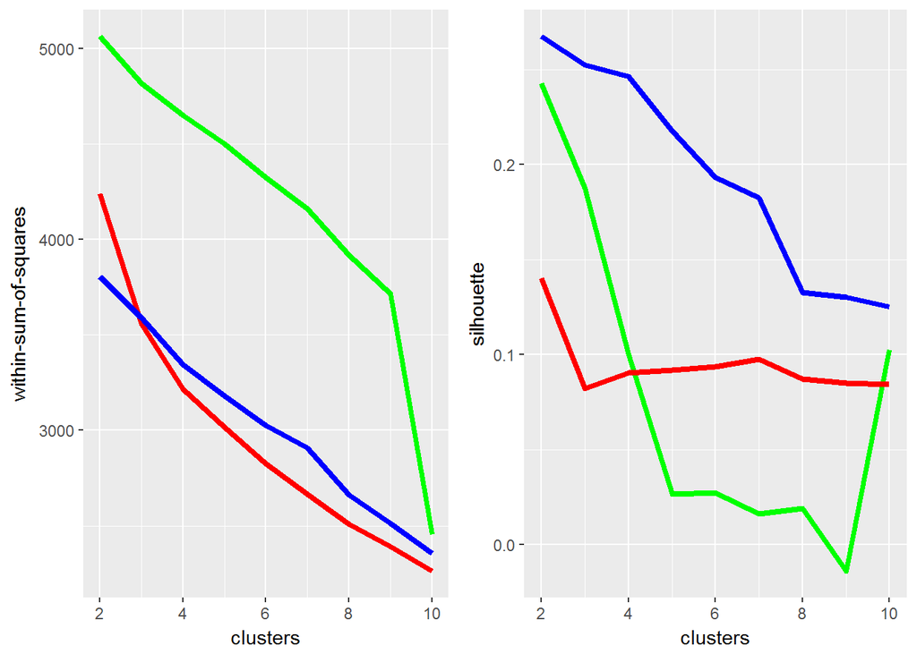

```r
#I am sure there are 3000 ways of doing this with less code but it is 11pm and I am exhausted

#I plot the figures within the same window
grid.arrange(ss, sil, ncol = 2)
```

```r
#And now to create the plots with a legend
sumofsquaresdf <- rbind(sumofsquaresdfsingle, sumofsquaresdfaverage)
sumofsquaresdf <- rbind(sumofsquaresdf, sumofsquaresdfcomplete)
sumofsquaresdf$method <- c(rep("single", 9), rep("average", 9), rep("complete", 9))
sumofsquaresdf
```

```
##    clusters withinss   method
## 1         2 5062.030   single
## 2         3 4818.276   single
## 3         4 4649.302   single
## 4         5 4501.464   single
## 5         6 4323.960   single
## 6         7 4159.574   single
## 7         8 3917.923   single
## 8         9 3713.634   single
## 9        10 2456.218   single
## 10        2 3803.959  average
## 11        3 3590.099  average
## 12        4 3343.589  average
## 13        5 3181.360  average
## 14        6 3027.724  average
## 15        7 2909.693  average
## 16        8 2662.768  average
## 17        9 2512.098  average
## 18       10 2356.856  average
## 19        2 4238.964 complete
## 20        3 3558.269 complete
## 21        4 3216.205 complete
## 22        5 3014.957 complete
## 23        6 2827.723 complete
## 24        7 2665.428 complete
## 25        8 2509.554 complete
## 26        9 2391.524 complete
## 27       10 2263.763 complete
```

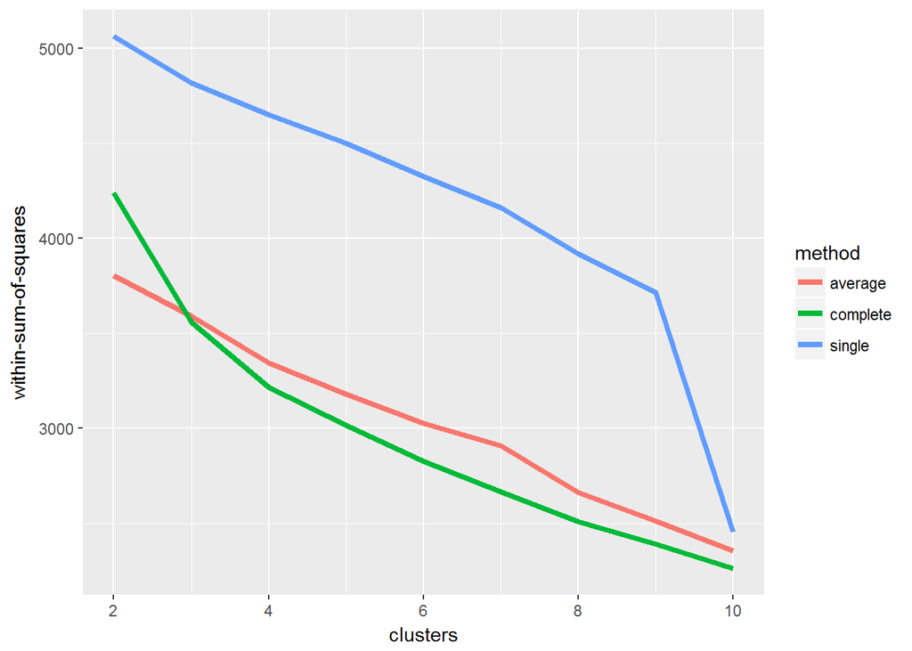

```r
ss2 <- ggplot(data = sumofsquaresdf, aes(x = clusters, y = withinss, group = method, color = method)) +
  geom_line(lwd = 1.5) +
  ylab("within-sum-of-squares")
ss2
```

```r
#And now to create the plots with a legend
sildf <- rbind(sildfsingle, sildfaverage)
sildf <- rbind(sildf, sildfcomplete)
sildf$method <- c(rep("single", 9), rep("average", 9), rep("complete", 9))
sildf
```

```
##    clusters  silhouette   method
## 1         2  0.24289354   single
## 2         3  0.18756934   single
## 3         4  0.09989940   single
## 4         5  0.02669164   single
## 5         6  0.02725293   single
## 6         7  0.01602596   single
## 7         8  0.01898130   single
## 8         9 -0.01399449   single
## 9        10  0.10245087   single
## 10        2  0.26751018  average
## 11        3  0.25262951  average
## 12        4  0.24647635  average
## 13        5  0.21787583  average
## 14        6  0.19346207  average
## 15        7  0.18262987  average
## 16        8  0.13269157  average
## 17        9  0.13007985  average
## 18       10  0.12532306  average
## 19        2  0.14008167 complete
## 20        3  0.08198639 complete
## 21        4  0.09032678 complete
## 22        5  0.09171477 complete
## 23        6  0.09350095 complete
## 24        7  0.09758324 complete
## 25        8  0.08724553 complete
## 26        9  0.08508545 complete
## 27       10  0.08434867 complete
```

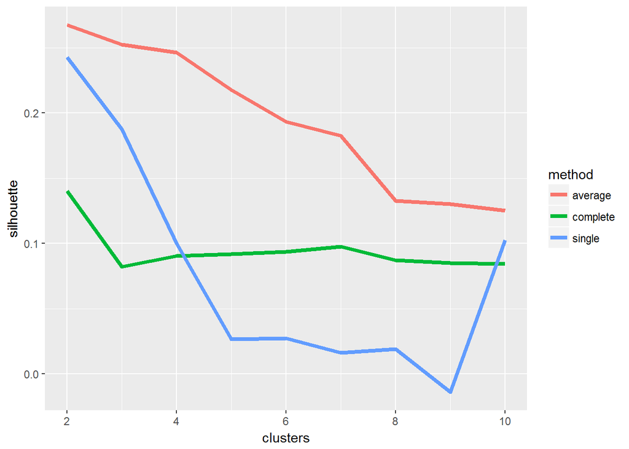

```r
sil2 <- ggplot(data = sildf, aes(x = clusters, y = silhouette, group = method, color = method)) +
  geom_line(lwd = 1.5) +
  ylab("silhouette")
sil2
```

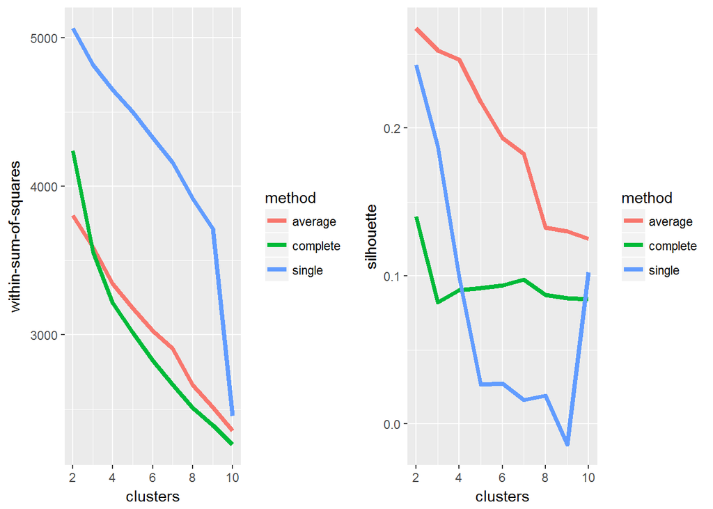

```r
#I plot the figures within the same window
grid.arrange(ss2, sil2, ncol = 2)
```

```r
## ANSWER 6
#Based on the graphs, average with 4 clusters is optimal because it reaches a good compromise between low within sum of squares and high average silhouette
```

I spent a total of 47 hours working 5 days in this This means: I spent all my weekend on this I could not prepare my patients for clinics I had to move patients in my clinics to attend office hours I still have to complete notes on my clinics for more than 3 days now I was working every day very very late I could not attend the bioinformatics seminar on Tuesday because I was trying to figure out things with the TAs My research is essentially stopped while I work every week in these problem sets I cannot work on homework for other courses. I am falling so behind working in the MIMIC dataset for the HST953 course If the objective of the problem sets is to destroy the working schedule of your students you are doing it very well. If that is not your goal, I would ask you to reconsider the length and time requirements of these assignments. If somebody asks me what I am learning with this, I would say I am learning something that I could have learned in 4-5 hours if problem sets were well designed. Struggling with code is good to a certain point, after some time, it is counterproductive. Thank you